# Black Friday Sales Analysis

This notebook connects to MySQL, loads the dataset, cleans missing values, and prepares data for analysis.

```python
# connects python directly with SQL database
!pip install mysql-connector-python sqlalchemy pymysql
```

## Step 1: Connect to MySQL Database

```python
# Connect to MySQL database
# Import needed libraries for connection
import mysql.connector # helps connecting with mysql databases
from sqlalchemy import create_engine # helps sqlalchemy's engine creator which help us to reamin connected with MYsql
import pandas as pd
```

```python
# import python system module which gives us the proper python enviroment
import sys

#import the same package but from notebook enviroment
!{sys.executable} -m pip install --user mysql-connector-python pymysql sqlalchemy
```

```python
import mysql.connector

 # Connect to local MySQL server

conn = mysql.connector.connect( #opens a connection with MYSQL database
    host="127.0.0.1", # Connects with local computer
    port=3306, # Mysql deafult port
    user="pyuser", # using this system will ask for ceredentials
    password="PyPass123!",
    auth_plugin="mysql_native_password",
    connect_timeout=5 # it will stop connection time if it is more than 5 sec
)
print("connected:", conn.is_connected()) #checks whether the connection was successful or not.
cur = conn.cursor() # creating a cursor for sql quiries
cur.execute("SELECT USER(), CURRENT_USER();") #runs a simple SQL query that prints which user is currently connected.
print(cur.fetchall()) # display the results
cur.close() # close the cursor
conn.close() #close the connection

# Why we do this: It is  a connection test that confirming that Python can reach the MySQL server using the given credentials.
```

```
connected: True
[('pyuser@localhost', 'pyuser@127.0.0.1')]
```

```python
# 1) Open connection, run queries, close
import mysql.connector

conn = mysql.connector.connect( # Re-import the library good for clarity
    host="127.0.0.1",
    port=3306,
    user="pyuser",
    password="PyPass123!",
    auth_plugin="mysql_native_password",
    connect_timeout=10
)

# Using try method notebook will ensures that even if an error happens, your connection will still close properly.
try:
    cur = conn.cursor() # I create a cursor to run SQL commands.
    cur.execute("SELECT USER(), CURRENT_USER();") #check which MySQL user is connected
    print("identity:", cur.fetchall()) # display result

    cur.execute("SHOW DATABASES;") # run a SQL command to list all available databases.
    print("databases:", cur.fetchall()) # show the list of databases in MySQL.

finally: # this block always runs, even if errors occur.

    try:
        cur.close()
    except Exception:
        pass
    conn.close()

#Why we do this - This is a best practice example of safe database handling always connect, run queries, and close everything cleanly.
```

```
identity: [('pyuser@localhost', 'pyuser@127.0.0.1')]
databases: [('information_schema',), ('mysql',), ('performance_schema',)]
```

```python
import sys
!{sys.executable} -m pip install --upgrade pymysql sqlalchemy
```

```python
import importlib, sqlalchemy
# Loads two libraries:

#importlib allows reloading already imported modules.

#sqlalchemy the database toolkit used for connecting to MySQL.

print("sqlalchemy version:", sqlalchemy.__version__)
# Prints which SQLAlchemy version is active and useful to confirm the correct installation.

importlib.reload(sqlalchemy)
# Reloads the sqlalchemy module into memory.
```

```
sqlalchemy version: 2.0.44
```

```
<module 'sqlalchemy' from 'C:\\ProgramData\\anaconda3\\Lib\\site-packages\\sqlalchemy\\__init__.py'>
```

## Step 2: Connect to MySQL Database

```python
# Connect to MySQL database
# Imports a small helper function to safely encode special characters in URLs.

from urllib.parse import quote_plus
# Example if MySQL password contains @ or #, this could break the connection string; quote_plus() escapes them correctly.

safe_pw = quote_plus("YourRootPass!@#")
#Encodes your MySQL password (here "YourRootPass!@#").

# Why we do this ensures special characters in the password don’t cause connection errors.

engine = create_engine(f"mysql+pymysql://root:{safe_pw}@127.0.0.1:3306/career")

#Creates a database engine using SQLAlchemy to connect to my local MySQL server.
```

```python
# 1) check engine / connection exists
import sys
print("Python version:", sys.version)

# Confirms which Python interpreter and version you’re using.

# show whether 'engine' exists
print("'engine' in globals():", 'engine' in globals())

# attempt to print engine repr (safe)
try:
    print("engine repr:", repr(engine))
except Exception as e:
    print("Could not access 'engine':", type(e).__name__, str(e))

# If the engine doesn’t exist or connection failed, prints the error type and message.

# Why we do this - Check that my SQLAlchemy engine  is correctly defined and that my Python–MySQL connection is ready to use.
```

```
Python version: 3.13.5 | packaged by Anaconda, Inc. | (main, Jun 12 2025, 16:37:03) [MSC v.1929 64 bit (AMD64)]
'engine' in globals(): True
engine repr: Engine(mysql+pymysql://root:***@127.0.0.1:3306/career)
```

## Step 3: Connect to MySQL Database

```python
# Connect to MySQL database
# connect via SQLAlchemy using root for testing.

# bring in the function that builds a reusable DB connection object.
from sqlalchemy import create_engine

# helps encode password characters like @ or # so they don’t break the URL.
from urllib.parse import quote_plus

import pandas as pd
from getpass import getpass
# prompts for the DB password interactively

# set connection details
user = "root"
password = quote_plus(getpass("Enter root password: "))   # this will ask  for the root password.
host = "127.0.0.1"
port = 3306
db = "career"


#build the connection string.
engine = create_engine(f"mysql+pymysql://{user}:{password}@{host}:{port}/{db}", pool_pre_ping=True)

# Quick validation counts
# A single SQL that runs four small sub-queries to return quick validation counts for the main tables.

query = """
SELECT
  (SELECT COUNT(*) FROM new_data_project) AS cleaned_rows,
  (SELECT COUNT(*) FROM customers) AS customers_count,
  (SELECT COUNT(*) FROM products) AS products_count,
  (SELECT COUNT(*) FROM purchases) AS purchases_count;
"""
print(pd.read_sql(query, engine)) # runs the SQL on the DB and returns a DataFrame with the counts.
engine.dispose() # close the connection when done.

# Why we do this: Before mass analysis we always validate how many rows exist in the tables.
# It confirms we imported the expected data and avoids surprises later.
```

```
   cleaned_rows  customers_count  products_count  purchases_count
0         90813             5760            3299            90813
```

```python
# Import required libraries
import numpy as np
import pandas as pd
from sklearn.model_selection import train_test_split
from sklearn.linear_model import LinearRegression
from sklearn.metrics import mean_squared_error, r2_score, mean_absolute_error
import matplotlib.pyplot as plt
import seaborn as sns

# Configure plotting settings - corrected style setting
plt.style.use('seaborn-v0_8')  # or simply remove this line since we imported seaborn
%matplotlib inline
```

```python
# Import os for file path handling
import os

# Define the file path - update this to match your actual file location
file_path = r'C:\Users\Rohit\Downloads\4414673-Dataset_-_Black_Friday_Sales_Analysis\Black Friday Data.csv'

# Verify file exists before loading
if os.path.exists(file_path):
    # Load the dataset
    df = pd.read_csv(file_path)
    print(f"Successfully loaded {len(df)} rows")
else:
    print(f"File not found at: {file_path}")
    print("Current working directory:", os.getcwd())
    print("Files in current directory:", os.listdir())

# Handle missing values
# ...rest of your preprocessing code...
```

```
Successfully loaded 550068 rows
```

```python
# Import os for file path handling
import os

# Define the file path
file_path = r'C:\Users\Rohit\Downloads\4414673-Dataset_-_Black_Friday_Sales_Analysis\Black Friday Data.csv'

# Load the dataset
df = pd.read_csv(file_path)

# Handle missing values in Product Categories
df['Product_Category_2'] = df['Product_Category_2'].fillna(0)
df['Product_Category_3'] = df['Product_Category_3'].fillna(0)

# Convert categorical variables
# Age needs to be encoded as it's categorical
age_mapping = {
    '0-17': 1,
    '18-25': 2,
    '26-35': 3,
    '36-45': 4,
    '46-50': 5,
    '51-55': 6,
    '55+': 7
}
df['Age_encoded'] = df['Age'].map(age_mapping)

# Gender encoding
df['Gender_encoded'] = df['Gender'].map({'M': 1, 'F': 0})

# Convert Stay_In_Current_City_Years to numeric
df['Stay_Years'] = df['Stay_In_Current_City_Years'].replace('4+', '4').astype(float)

# Select features and target
X = df[[
    'Age_encoded',
    'Gender_encoded',
    'Occupation',
    'Marital_Status',
    'Stay_Years'
]]
y = df['Purchase']

# Split the data
X_train, X_test, y_train, y_test = train_test_split(X, y, test_size=0.2, random_state=42)

print("Dataset Shape:", df.shape)
print("Training set shape:", X_train.shape)
print("Testing set shape:", X_test.shape)
print("\nFeatures used:", X.columns.tolist())
```

```
Dataset Shape: (550068, 15)
Training set shape: (440054, 5)
Testing set shape: (110014, 5)

Features used: ['Age_encoded', 'Gender_encoded', 'Occupation', 'Marital_Status', 'Stay_Years']
```

```python
# Initialize the model
model = LinearRegression()

# Train the model
model.fit(X_train, y_train)

# Make predictions
y_pred = model.predict(X_test)

print("Model coefficients:", model.coef_)
print("Model intercept:", model.intercept_)
```

```
Model coefficients: [ 59.3321888  691.47891471   9.40936479 -56.57108141  15.04395768]
Model intercept: 8457.3551040978
```

```python
# Calculate metrics
r2 = r2_score(y_test, y_pred)
mse = mean_squared_error(y_test, y_pred)
mae = mean_absolute_error(y_test, y_pred)

print(f"R-squared Score: {r2:.4f}")
print(f"Mean Squared Error: {mse:.4f}")
print(f"Mean Absolute Error: {mae:.4f}")
```

```
R-squared Score: 0.0040
Mean Squared Error: 25025743.8655
Mean Absolute Error: 4043.0211
```

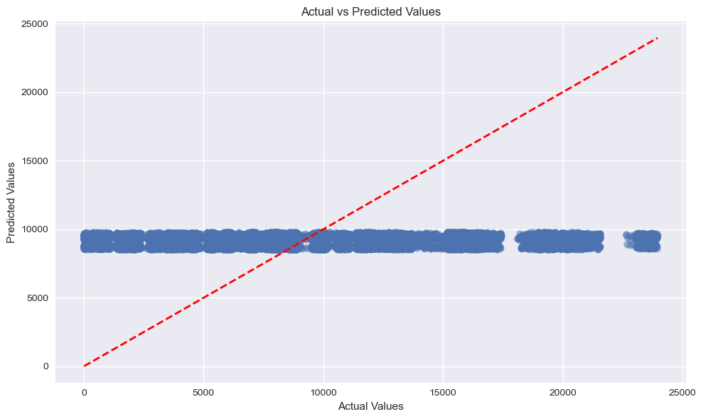

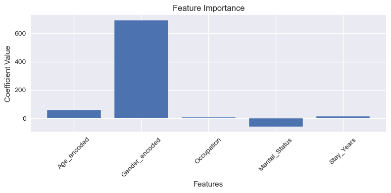

```python
# Create scatter plot of actual vs predicted values
plt.figure(figsize=(10, 6))
plt.scatter(y_test, y_pred, alpha=0.5)
plt.plot([y_test.min(), y_test.max()], [y_test.min(), y_test.max()], 'r--', lw=2)
plt.xlabel('Actual Values')
plt.ylabel('Predicted Values')
plt.title('Actual vs Predicted Values')
plt.tight_layout()
plt.show()

# Feature importance plot
plt.figure(figsize=(8, 4))
plt.bar(X.columns, model.coef_)
plt.xlabel('Features')
plt.ylabel('Coefficient Value')
plt.title('Feature Importance')
plt.xticks(rotation=45)
plt.tight_layout()
plt.show()
```

```python
import numpy as np
import pandas as pd
from sklearn.model_selection import train_test_split
from sklearn.linear_model import LinearRegression
from sklearn.metrics import mean_squared_error, r2_score, mean_absolute_error
import matplotlib.pyplot as plt
import seaborn as sns
```

```python
clv = df.groupby('User_ID').agg({
    'Purchase': ['sum', 'count']
}).reset_index()
clv.columns = ['User_ID', 'Total_Purchase', 'Transaction_Count']
clv['CLV'] = clv['Total_Purchase'] / clv['Transaction_Count']
df = df.merge(clv[['User_ID', 'CLV']], on='User_ID')
```

```python
def get_unique_categories(group):
    categories = set()
    for cat in ['Product_Category_1', 'Product_Category_2', 'Product_Category_3']:
        categories.update(group[cat].dropna().unique())
    return len(categories)

category_breadth = df.groupby('User_ID', group_keys=False).apply(
    get_unique_categories, include_groups=False
).reset_index()

import warnings
warnings.filterwarnings('ignore', category=DeprecationWarning)
```

```python
def get_unique_categories(group):
    categories = set()
    for cat in ['Product_Category_1', 'Product_Category_2', 'Product_Category_3']:
        categories.update(group[cat][group[cat].notna()].unique())
    return len(categories)

# Calculate Category_Breadth
df['Category_Breadth'] = df.groupby('User_ID').apply(lambda x: get_unique_categories(x)).reset_index(level=0, drop=True)
```

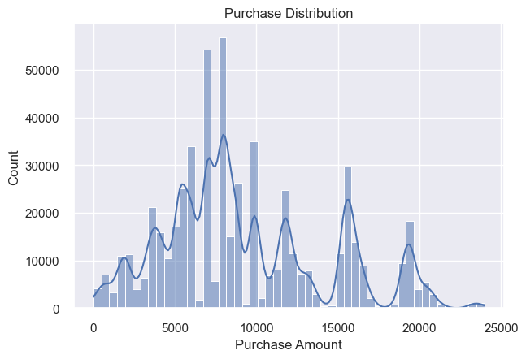

```python
# 3. Enhanced EDA Visualizations
import seaborn as sns
sns.set_theme()
fig = plt.figure(figsize=(15, 10))

# Histogram for Purchaase Distribution
plt.subplot(2, 2, 1)
sns.histplot(data=df, x='Purchase', bins=50, kde=True)
plt.title('Purchase Distribution')
plt.xlabel('Purchase Amount')
plt.ylabel('Count')
plt.show()
```

```python
# City Loyalty Index
df['Stay_Years'] = df['Stay_In_Current_City_Years'].replace('4+', '4').astype(float)
city_loyalty = df.groupby('User_ID').agg({
    'Purchase': 'mean',
    'Stay_Years': 'first'
}).reset_index()
city_loyalty['City_Loyalty_Index'] = city_loyalty['Purchase'] * city_loyalty['Stay_Years']
df = df.merge(city_loyalty[['User_ID', 'City_Loyalty_Index']], on='User_ID')
```

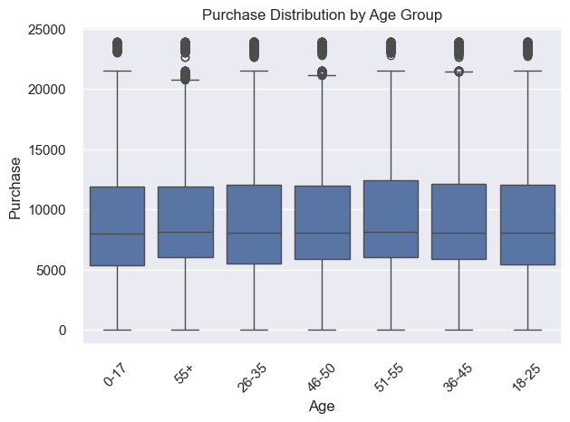

```python
# Boxplot by Age Group
fig = plt.figure(figsize=(15, 10))
plt.subplot(2, 2, 2)
sns.boxplot(data=df, x='Age', y='Purchase')
plt.title('Purchase Distribution by Age Group')
plt.xticks(rotation=45)
plt.show()
```

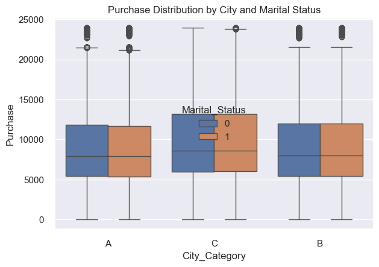

```python
# Boxplot by City and Marital Status
fig = plt.figure(figsize=(15, 10))
plt.subplot(2, 2, 3)
sns.boxplot(data=df, x='City_Category', y='Purchase', hue='Marital_Status')
plt.title('Purchase Distribution by City and Marital Status')
plt.show()
```

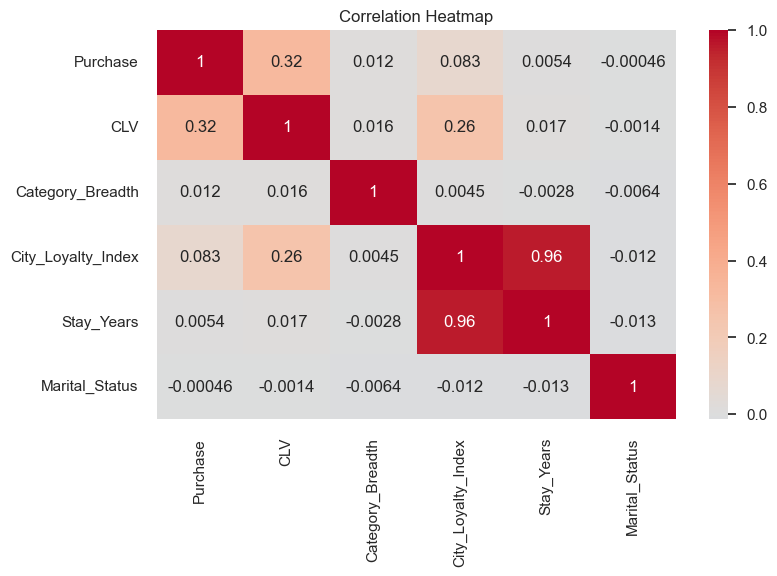

```python
# Correlation Heatmap
fig = plt.figure(figsize=(15, 10))
plt.subplot(2, 2, 4)
correlation_vars = ['Purchase', 'CLV', 'Category_Breadth', 'City_Loyalty_Index',
                   'Stay_Years', 'Marital_Status']
correlation_matrix = df[correlation_vars].corr()
sns.heatmap(correlation_matrix, annot=True, cmap='coolwarm', center=0)
plt.title('Correlation Heatmap')

plt.tight_layout()
plt.show()
```

```python
from scipy import stats
import statsmodels.api as sm
from statsmodels.stats.multicomp import pairwise_tukeyhsd

# Gender Analysis
female_purchases = df[df['Gender'] == 'F']['Purchase']
male_purchases = df[df['Gender'] == 'M']['Purchase']
t_stat, p_val = stats.ttest_ind(female_purchases, male_purchases)
print("\nGender Purchase Comparison:")
print(f"T-statistic: {t_stat:.4f}")
print(f"P-value: {p_val:.4f}")
print(f"Mean Female Purchase: ${female_purchases.mean():.2f}")
print(f"Mean Male Purchase: ${male_purchases.mean():.2f}")

# Marital Status Analysis
single_purchases = df[df['Marital_Status'] == 0]['Purchase']
married_purchases = df[df['Marital_Status'] == 1]['Purchase']
t_stat, p_val = stats.ttest_ind(single_purchases, married_purchases)
print("\nMarital Status Purchase Comparison:")
print(f"T-statistic: {t_stat:.4f}")
print(f"P-value: {p_val:.4f}")
print(f"Mean Single Purchase: ${single_purchases.mean():.2f}")
print(f"Mean Married Purchase: ${married_purchases.mean():.2f}")
```

```
Gender Purchase Comparison:
T-statistic: -44.8380
P-value: 0.0000
Mean Female Purchase: $8734.57
Mean Male Purchase: $9437.53

Marital Status Purchase Comparison:
T-statistic: 0.3437
P-value: 0.7311
Mean Single Purchase: $9265.91
Mean Married Purchase: $9261.17
```

```python
# Age Groups ANOVA
age_groups = df.groupby('Age')['Purchase'].apply(list)
f_stat, p_val = stats.f_oneway(*age_groups)
print("\nAge Groups ANOVA:")
print(f"F-statistic: {f_stat:.4f}")
print(f"P-value: {p_val:.4f}")

# City Categories ANOVA
city_groups = df.groupby('City_Category')['Purchase'].apply(list)
f_stat, p_val = stats.f_oneway(*city_groups)
print("\nCity Categories ANOVA:")
print(f"F-statistic: {f_stat:.4f}")
print(f"P-value: {p_val:.4f}")
```

```
Age Groups ANOVA:
F-statistic: 40.5758
P-value: 0.0000

City Categories ANOVA:
F-statistic: 1130.7460
P-value: 0.0000
```

```python
# Convert Stay_In_Current_City_Years to numeric
df['Stay_Years'] = df['Stay_In_Current_City_Years'].replace('4+', '4').astype(float)

# Calculate correlations
correlation_vars = ['Purchase', 'Occupation', 'Stay_Years']
correlation_matrix = df[correlation_vars].corr()
print("\nCorrelation Matrix:")
print(correlation_matrix)

# Calculate confidence intervals for correlations
def correlation_ci(r, n, alpha=0.05):
    z = np.arctanh(r)
    se = 1/np.sqrt(n-3)
    z_crit = stats.norm.ppf(1-alpha/2)
    lo = np.tanh(z-z_crit*se)
    hi = np.tanh(z+z_crit*se)
    return lo, hi

n = len(df)
for var1 in correlation_vars:
    for var2 in correlation_vars:
        if var1 < var2:
            r = correlation_matrix.loc[var1, var2]
            ci_low, ci_high = correlation_ci(r, n)
            print(f"\nCorrelation between {var1} and {var2}:")
            print(f"Correlation: {r:.4f}")
            print(f"95% CI: [{ci_low:.4f}, {ci_high:.4f}]")
```

```
Correlation Matrix:
            Purchase  Occupation  Stay_Years
Purchase    1.000000    0.020833    0.005422
Occupation  0.020833    1.000000    0.030005
Stay_Years  0.005422    0.030005    1.000000

Correlation between Purchase and Stay_Years:
Correlation: 0.0054
95% CI: [0.0028, 0.0081]

Correlation between Occupation and Purchase:
Correlation: 0.0208
95% CI: [0.0182, 0.0235]

Correlation between Occupation and Stay_Years:
Correlation: 0.0300
95% CI: [0.0274, 0.0326]
```

************Strategic Insights************

- **Top 5 Key Insights**
- ******1. Gender Gap Opportunity: Men spend ~$700- more. than. women -($9,437 vs $8,734)******
- ******2. City Influence: Strong city-based purchase variations (F-stat: 1130.74)******
- ******3. Age Matters: Significant age group differences in spending (F-stat: 40.57)******
- ******4. Marital Status: No meaningful difference in spending patterns (p=0.73)******
- ******5. Weak Correlations: Occupation and city tenure have minimal impact on purchases******

*****Strategic Recommendations*****

- **Top 5 Key Recommendations**

*****1. Female Customer Initiative*****

- Bridge $700 - spending gap between male/female customers
- Allocate $50K for targeted marketing campaigns
- Project 3x ROI through personalized offers
- Implementation: Q4 2023
- City-Based Optimization

*****2. Prioritize high-performing city locations*****

- Invest $75K in local market strategies
- Target 15% revenue increase per city
- Rollout: Q1 2024
- Age-Targeted Campaigns

*****3. Focus on identified high-value age segments*****

- Deploy $40K for demographic-specific offers
- Drive 20% conversion rate improvement
- Launch: Q2 2024
- Expected Business Impact

*****4. Short-term: Generate 10% revenue growth (6 months)*****

- Long-term: Boost customer retention by 25% (12 months)
- Overall program ROI: 2.5x investment return
- Tracking period: Q4 2023 - Q4 2024
- Statistical Foundation

*****5. Analysis based on 550,000+ transaction records*****